# 건축심화세미나 - 팀 커뮤니케이션에 동적 문서인 “주피터노트북” 도입

: **AISC360을 .ipynb 화**

동적문서라는 말이 학술적으로 있는 건 아니고요. 제가 그냥 기존 pdf와 반대되는 개념으로 이름을 붙여봤습니다.  
(동적페이지, 정적페이지 라는 말은 웹 개발에서 사용하는 말입니다.)

문서는 문서인데, 프로그램처럼 동작하는 문서라서  
하나의 문서가 사용자가 의도한 결과값을 만들어주는 프로그램처럼 동작합니다.

요약: 주피터 노트북은 text document, code, 수식, 그래프, 코드 결과를 하나의 파일 (.ipynb)에 담을 수 있는 장점이 있습니다.

## 주피터 노트북

[figure not shown]

주피터노트북이란..

- "문서와 웹애플리케이션을 합친 형태" 의 문서이고,
- python, nodejs, clojure 등의 여러 언어를 지원합니다.
- 문서는 다수의 "셀" 이 모여서 이루어지며, 셀 하나는 그 자체로 코드를 실행할 수 있는 틀이기도 합니다.
- 마크다운 문법을 지원하며, 마크다운 셀과 코드 실행 셀을 번갈아 배치하는 것으로 써, 설명과 예제를 동시에 포함하는 문서로 동작합니다.

[참조링크](https://github.com/mcleonard/blog_posts/blob/master/body_fat_percentage.ipynb)

## 주로 어디에 쓰나?

데이터 사이언스에서 주로 사용하는데, 점점 사용처가 늘어나고 있습니다.

엑셀을 통해 우리는 이미 기존 업무에서 간단한 코딩을 해왔기 때문에,  
이 흐름을 주피터 노트북으로 옮기게 되면, 파이썬 기반으로 살아움직이는 문서를 만들고,  
프로젝트마다 달라지는 인풋값만 변경하면서 쉽게 업무를 공유할 수 있습니다.

# pdf, word 와 다른점

## 글자인가, 코드인가?

주피터노트북에서는 엑셀처럼 입력값에 따라 다른 결과물을 반환해주는 코드입니다.

```python
##### 사용자 입력 1 ########
Fcr = 300
Ag = 0.84
```

```python
##### 사용자 입력 2 ########
Fcr = 350
Ag = 1.07
```

```python
##### 사용자 입력 3 ########
Fcr = 450
Ag = 1.12
```

```python
##### 계산식 ########
Pn = Fcr * Ag


##### 결과 출력 ########
print(Pn)
```

```
504.00000000000006
```

## slide로 보기도 편하다 (feat. RISE package)

지금 보고 계신 화면이, 주피터 노트북 파일을 별도의 변환없이 바로 슬라이드로 보고 계신겁니다.

별다른 설명은 필요없겠죠?

주피터 노트북에서 이 기능을 쓰려면, RISE 라는 패키지가 필요합니다.  
설치가 엄청 간단한 데 비해서 장점이 좋습니다.

- 주피터 노트북 안에서 슬라이드 쇼 모드로 바로 변경 가능
- 슬라이드 쇼 내에서 코드 실행 가능

그래도 설치환경 구성이 자신이 없으신 분들이 당연히 계실 텐 데요.

도커를 활용해서 설치환경 자체를 컨테이너로 배포할 수 있습니다.  
뒤에서 자세히 설명할게요.

# excel 보다 편한점 (문서작성 예시)

"그냥 엑셀로 할래요..."

라는 질문이 왜인지 나올것 같아서 한가지 말씀드리자면,

엑셀을 버리자라는 의도는 아닙니다.

엑셀도 당연히 쓸건데요.

이제는 엑셀은 협업툴로써의 역할은 좀 축소되어야 한다고 생각합니다.(가능한 만큼만 단계적으로요.)

> 엑셀과 같은 스프레드시트는 개인적인 스케치용도나  
> 혹은 데이터베이스 원본 용도로 사용하는 것이 적합하다

라고 개인적으로는 생각하고 있습니다.

또한 수식입력도 "$" 문자를 두번 사용하여 깔끔하게 입력됩니다.(LaTEX 지원)

예시)

$\frac{F_y} {F_e} \leq 2.25$

다음 슬라이드 부터는 주피터노트북으로 작성하는 문서의 예시입니다.  
멀티엔지니어 압축부재 관련내용 정리하는 과제를 주피터 노트북으로 수행한 것입니다.

## E1. GENERAL PROVISIONS

The design compressive strength, φcPn, and the allowable compressive strength, Pn/Ωc, are determined as follows. The nominal compressive strength, Pn, shall be the lowest value obtained based on the applicable limit states of flexural buckling, torsional buckling, and flexural-torsional buckling

$$φ_c = 0.90 (LRFD)$$

$$Ω_c = 1.67 (ASD)$$

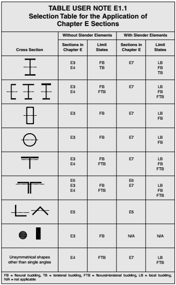

## E2. EFFECTIVE LENGTH

The effective length, $L_c$, for calculation of member slenderness, $L_c/r$, shall be determined in accordance with Chapter C or Appendix 7,

where  
$K =$ effective length factor  
$L_c = KL =$ effective length of member, in. (mm)  
$L =$ laterally unbraced length of the member, in. (mm)  
$r =$ radius of gyration, in. (mm)

`User Note: For members designed on the basis of compression, the effective slenderness ratio, L c/r, preferably should not exceed 200.`

`User Note: The effective length, Lc, can be determined through methods other than those using the effective length factor, K.`

## E3. FLEXURAL BUCKLING OF MEMBERS WITHOUT SLENDER ELEMENTS

This section applies to nonslender-element compression members, as defined in Section B4.1, for elements in axial compression.

`User Note: When the torsional effective length is larger than the lateral effective length, Section E4 may control the design of wide-flange and similarly shaped columns.`

The nominal compressive strength, $Pn$, shall be determined based on the limit state of flexural buckling:

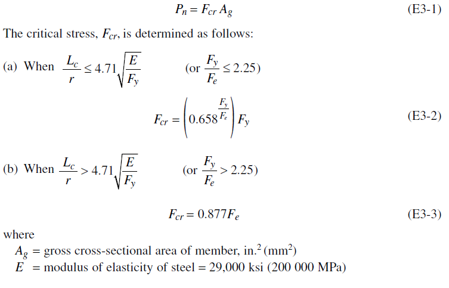

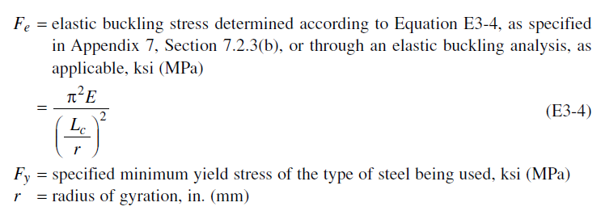

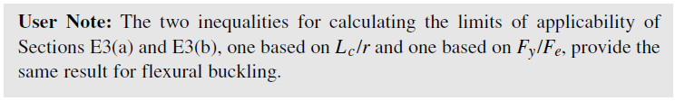

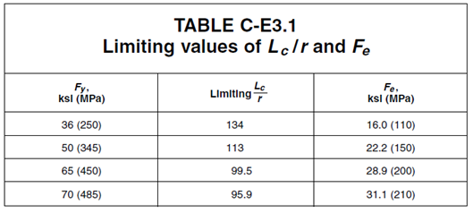

```python
def findFcr(E, Fy, sldns):
    Fe = pi**2 * E / (sldns ** 2)

    if sldns <= 4.71*math.sqrt(E/Fy):
        Fcr = math.pow(0.658, Fy/Fe) * Fy
    else:
        Fcr = 0.877 * Fe

    return Fcr
```

```python
result = lambda a: [findFcr(250000, a, x) for x in range(1,201)] ## 탄성계수 입력
res250 = result(250)
res345 = result(345)
res345
```

```
[344.9798101340706,
 344.919247625235,
 344.8183337362034,
 344.6771038910017,
 344.4956076542477,
 344.2739087021612,
 344.01208478533135,
 343.7102276832731,
 343.3684431508089,
 342.98685085631945,
 342.5655843119146,
 342.1047907955812,
 341.60463126537115,
 341.0652802656998,
 340.48692582583163,
 339.86976935063456,
 339.2140255036936,
 338.5199220828768,
 337.7876998884558,
 337.0176125838878,
 336.2099265493708,
 335.36492072829117,
 334.4828864666877,
 333.56412734586,
 332.6089590082581,
 331.6177089767908,
 330.5907164676992,
 329.5283321971439,
 328.43091818166147,
 327.29884753264736,
 326.1325042450302,
 324.93228298030397,
 323.69858884409007,
 322.431837158404,
 321.132453228807,
 319.80087210662384,
 318.4375383464139,
 317.0429057588835,
 315.6174371594327,
 314.1616041125309,
```

[output cut: 145 more lines]

```
 62.5480045363291,
 61.88083059106184,
 61.22427469836016,
 60.57811273309375,
 59.94212645259948,
 59.31610331237745,
 58.69983628848855,
 58.09312370637712,
 57.49576907585401,
 56.907580931987944,
 56.32837268166497,
 55.75796245558611,
 55.19617296548417,
 54.642831366350386,
 54.09776912347104]
```

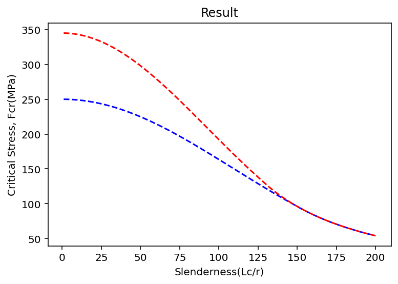

```python
plt.plot(range(1,201), res250, 'b--')
plt.plot(range(1,201), res345, 'r--')

plt.xlabel("Slenderness(Lc/r)")
plt.ylabel("Critical Stress, Fcr(MPa)")
plt.title("Result")
plt.show()
```

## E4. TORSIONAL AND FLEXURAL-TORSIONAL BUCKLING OF SINGLE ANGLES AND MEMBERS WITHOUT SLENDER ELEMENTS

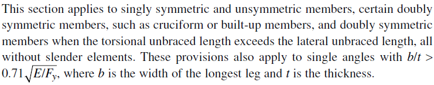

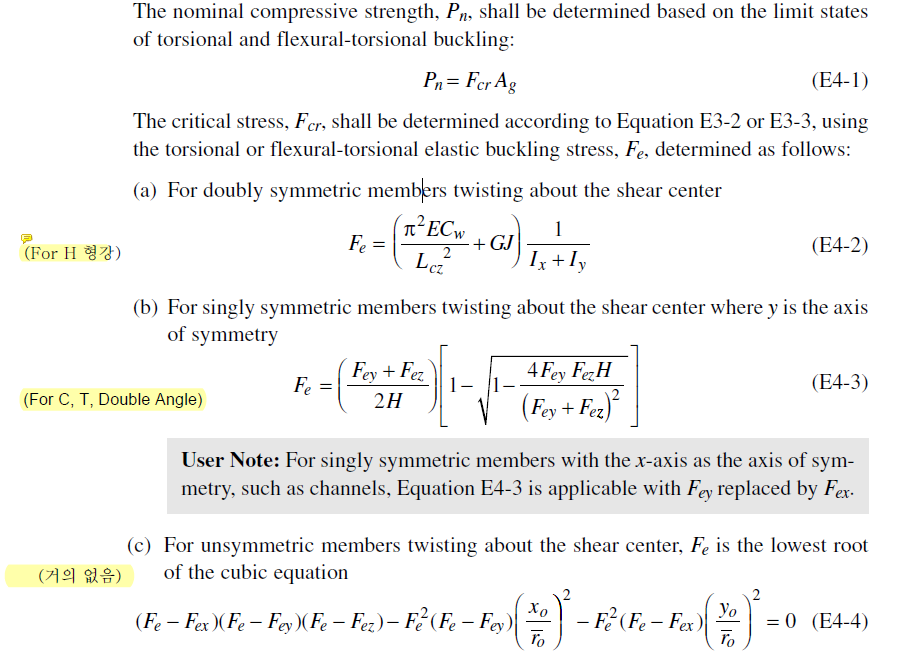

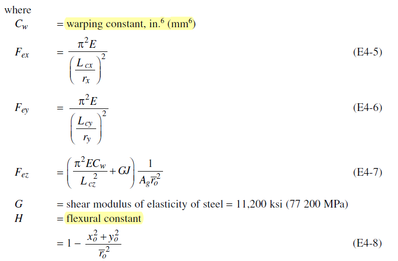

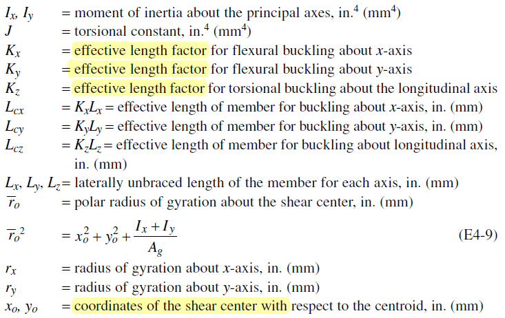

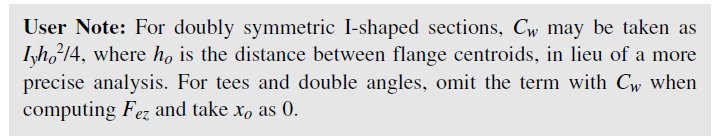

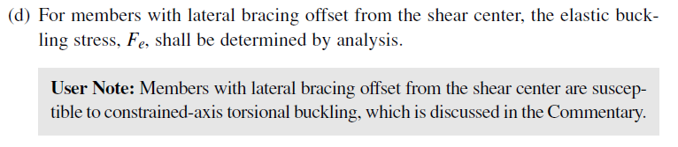

## EXAMPLE E.1D W-SHAPE AVAILABLE STRENGTH CALCULATION

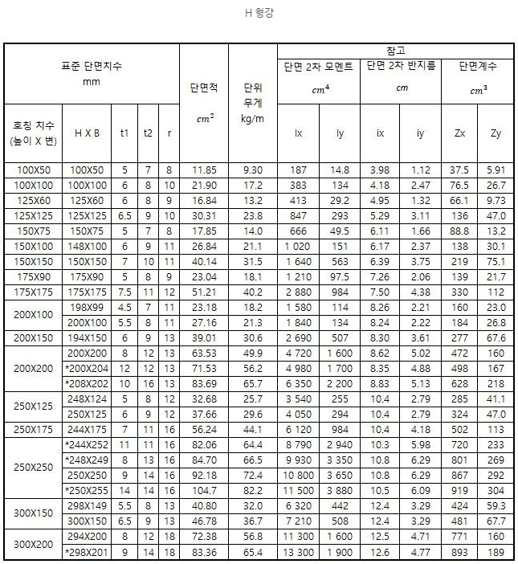

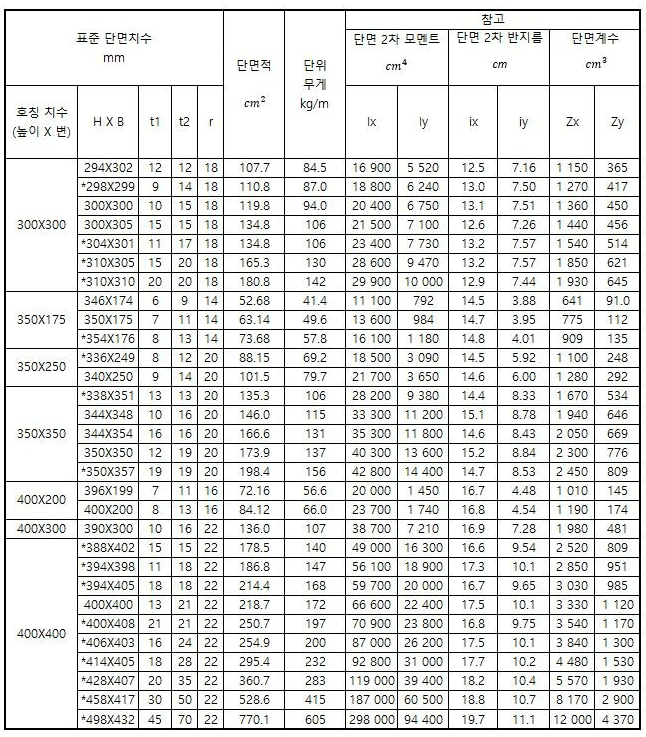

### Given:

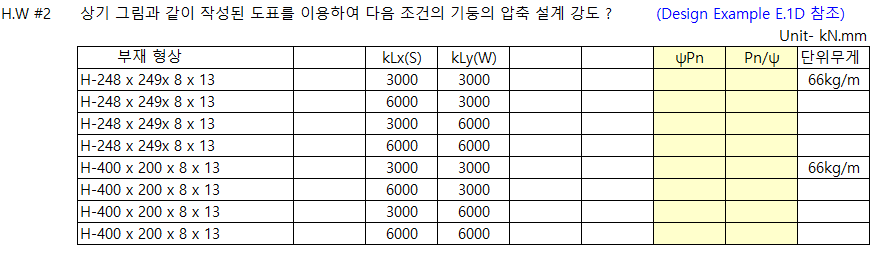

```python
mydata = {
    "size": [
        "H-248 x 249x 8 x 13",
        "H-248 x 249x 8 x 13",
        "H-248 x 249x 8 x 13",
        "H-248 x 249x 8 x 13",
        "H-400 x 200 x 8 x 13",
        "H-400 x 200 x 8 x 13",
        "H-400 x 200 x 8 x 13",
        "H-400 x 200 x 8 x 13",
    ],
    "Lx": [
        3000,
        6000,
        3000,
        6000,
        3000,
        6000,
        3000,
        6000,
    ],
    "Ly": [
        3000,
        3000,
        6000,
        6000,
        3000,
        3000,
        6000,
        6000,
    ],
    "Ag": [
        8470,
        8470,
        8470,
        8470,
        8412,
        8412,
        8412,
        8412,
    ],
    "rx": [
        108,
        108,
        108,
        108,
        168,
        168,
        168,
        168,
    ],
    "ry": [
        62.9,
        62.9,
        62.9,
        62.9,
        45.4,
        45.4,
        45.4,
        45.4,
    ],
}
```

### Solution:

### Fy = 250

```python
Fy = 250
E = 200000
Ag = 84.7*10**2 ## (mm2)
K = 1
Lx = 3000
Ly = 3000
rx = 10.8 * 10 ## radius of gyration
ry = 6.29 * 10 ## radius of gyration
```

#### Slenderness Check

```python
def designStrength(_Fy, _E, _K, mydata, i):
    Fy = _Fy
    E = _E
    size = mydata["size"][i]
    Ag = mydata["Ag"][i]
    K = _K
    Lx = mydata["Lx"][i]
    Ly = mydata["Ly"][i]
    rx = mydata["rx"][i]
    ry = mydata["ry"][i]

    def govSldns(K, Lx, Ly, rx, ry):
        def chckSldns(K, L, r):
            return (K * L) / r
        Sldns_x = chckSldns(K, Lx, rx)
        Sldns_y = chckSldns(K, Ly, ry)
        gov = max(Sldns_x, Sldns_y)
        return gov
    sldns = govSldns(K, Lx, Ly, rx, ry)
    Fcr = findFcr(E, Fy, sldns)
    Pn = Fcr * Ag / 1000 ## kN
    φc = 0.9
    Ωc = 1.67
    LRFD = φc * Pn
    ASD = Pn / 1.67

    result = {
        "부재형상" : size,
        "kLx" : Lx,
        "kLy" : Ly,
        "φPn" : LRFD,
        "Pn/Ω" : ASD,
    }

    return result
```

#### Critical Stress

### Design Compressive Strength

#### Case 1. Fy = 250 MPa

```python
result = [designStrength(250, 200000, 1, mydata, i) for i in range(len(mydata["size"]))]
data = pd.DataFrame(result)
```

```python
data
```

|  | 부재형상 | kLx | kLy | φPn | Pn/Ω |
| --- | --- | --- | --- | --- | --- |
| 0 | H-248 x 249x 8 x 13 | 3000 | 3000 | 1689.257346 | 1123.923717 |
| 1 | H-248 x 249x 8 x 13 | 6000 | 3000 | 1618.119151 | 1076.592915 |
| 2 | H-248 x 249x 8 x 13 | 3000 | 6000 | 1176.482522 | 782.756169 |
| 3 | H-248 x 249x 8 x 13 | 6000 | 6000 | 1176.482522 | 782.756169 |
| 4 | H-400 x 200 x 8 x 13 | 3000 | 3000 | 1501.609516 | 999.074861 |
| 5 | H-400 x 200 x 8 x 13 | 6000 | 3000 | 1501.609516 | 999.074861 |
| 6 | H-400 x 200 x 8 x 13 | 3000 | 6000 | 749.864339 | 498.911736 |
| 7 | H-400 x 200 x 8 x 13 | 6000 | 6000 | 749.864339 | 498.911736 |

#### Case 2. Fy = 345 MPa

```python
result = [designStrength(345, 200000, 1, mydata, i) for i in range(len(mydata["size"]))]
data = pd.DataFrame(result)
```

```python
data
```

|  | 부재형상 | kLx | kLy | φPn | Pn/Ω |
| --- | --- | --- | --- | --- | --- |
| 0 | H-248 x 249x 8 x 13 | 3000 | 3000 | 2226.764351 | 1481.546475 |
| 1 | H-248 x 249x 8 x 13 | 6000 | 3000 | 2098.401174 | 1396.141832 |
| 2 | H-248 x 249x 8 x 13 | 3000 | 6000 | 1351.642987 | 899.296731 |
| 3 | H-248 x 249x 8 x 13 | 6000 | 6000 | 1351.642987 | 899.296731 |
| 4 | H-400 x 200 x 8 x 13 | 3000 | 3000 | 1897.739886 | 1262.634654 |
| 5 | H-400 x 200 x 8 x 13 | 6000 | 3000 | 1897.739886 | 1262.634654 |
| 6 | H-400 x 200 x 8 x 13 | 3000 | 6000 | 750.378380 | 499.253746 |
| 7 | H-400 x 200 x 8 x 13 | 6000 | 6000 | 750.378380 | 499.253746 |

# 접근성

## Anaconda

[figure not shown]

https://www.anaconda.com/

## GroomIDE

[figure not shown]

https://ide.goorm.io/

## Docker

[figure not shown]

https://www.docker.com/products/docker-desktop

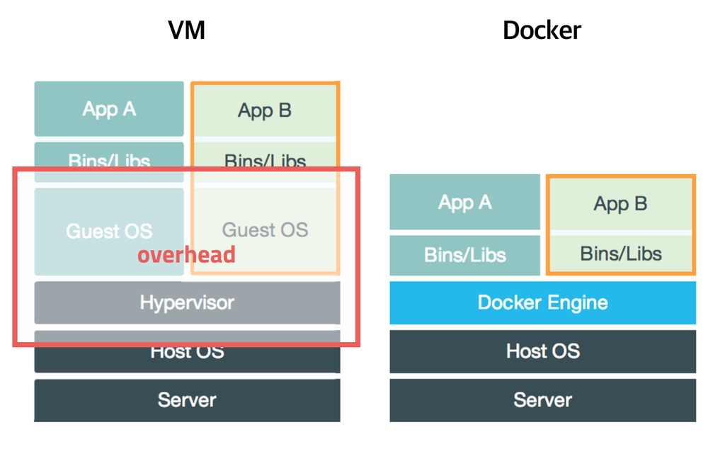

수년 동안 애플리케이션과 종속물(종속성)을 분리해 체계화할 때 많이 사용한 방법 중 하나는 각 애플리케이션을 각각 가상 머신에 배치하는 방법이었다. 가상 머신을 이용하면, 동일한 물리적 하드웨어에서 여러 애플리케이션을 실행시키고, 소프트웨어 구성 요소 간 충돌과 하드웨어 리소스 경합을 최소한으로 유지할 수 있다. 그러나 가상 머신은 그 크기가 일반적으로 기가바이트급이다. 이식성(이동성), 소프트웨어 업데이트, 지속적인 통합과 전달(Continuous Integration, CI/ Continuous Delivery, CD) 같은 문제 해결에도 도움을 주지 못한다.

여기에 도커(Docker) 컨테이너가 필요하다. 컨테이너를 활용하면, 운영체제 커널을 공유하는 작고 가벼운 실행 환경으로 애플리케이션을 분리시킬 수 있다. 통상 메가바이트급 크기인 컨테이너는 가상 머신 보다 리소스를 훨씬 적게 사용하고, 그 즉시 시작할 수 있다. 동일한 하드웨어에서 훨씬 더 높은 밀도로 패키징할 수 있으며, 훨씬 적은 노력과 비용으로 대량 축소 및 확장할 수 있다는 장점이 있다.

# 결론: AISC360 to Jupyter Notebook

팀에서 주피터 노트북이 공유가 되려면 첫 스타트가 필요하다고 봅니다.  
그래서 **AISC360 코드 전문을 동적문서로** 바꾸어서 팀에 공유하는 프로젝트를 제안드립니다.

감사합니다.